# Case Study - a new marketing strategy for a bike-sharing company

## Scenario

I am assuming the role of a junior data analyst working in the marketing analyst team at Cyclistic, a bike-share company in Chicago. The director of marketing believes the company’s future success depends on maximizing the number of annual memberships. Therefore, the team wants to understand how casual riders and annual members use Cyclistic bikes diﬀerently. From these insights, they will design a new marketing strategy to convert casual riders into annual members. But ﬁrst, Cyclistic executives must approve these recommendations, so they must be backed up with compelling data insights and professional data visualizations.

## About the company

In 2016, Cyclistic launched a successful bike-share oﬀering. Since then, the program has grown to a ﬂeet of 5,824 bicycles that are geotracked and locked into a network of 692 stations across Chicago. The bikes can be unlocked from one station and returned to any other station in the system anytime. Until now, Cyclistic’s marketing strategy relied on building general awareness and appealing to broad consumer segments. One approach that helped make these things possible was the ﬂexibility of its pricing plans: single-ride passes, full-day passes, and annual memberships. Customers who purchase single-ride or full-day passes are referred to as casual riders. Customers who purchase annual memberships are Cyclistic members. Cyclistic’s ﬁnance analysts have concluded that annual members are much more proﬁtable than casual riders. Although the pricing ﬂexibility helps Cyclistic attract more customers, Moreno believes that maximizing the number of annual members will be key to future growth. Rather than creating a marketing campaign that targets all-new customers, Moreno believes there is a very good chance to convert casual riders into members. She notes that casual riders are already aware of the Cyclistic program and have chosen Cyclistic for their mobility needs. Moreno has set a clear goal: Design marketing strategies aimed at converting casual riders into annual members. In order to do that, however, the marketing analyst team needs to better understand how annual members and casual riders diﬀer, why casual riders would buy a membership, and how digital media could aﬀect their marketing tactics. Moreno and her team are interested in analyzing the Cyclistic historical bike trip data to identify trends.

## I: ASK

I have been assigned by Moreno the following question : “how do annual members and casual riders use Cyclistic differently?”

### How can my insights help drive business decisions?

understanding the differences between members and casual riders would help us develop a marketing strategy to convert more casual riders to annual members

### The business task

determine the differences between members and casual riders

## II: Prepare

### Where is the data located?

The data is a public [dataset](https://divvy-tripdata.s3.amazonaws.com/index.html) under the [license](https://www.divvybikes.com/data-license-agreement) that was made available by Motivate international INC. The information of the last 12 months was downloaded and saved under the directory “/data”.

### How is the data orgainzed?

The data consists of 12 csv files. Each file is a table of the following 13 columns : (ride_id, rideable_type [electric - classic - docked], started_at [datetime], ended_at [datetime], start_station_name, start_staiton_id, end_station_name, end_station_id, start_lat, start_lng, end_lat, end_lng, member_causal [member - casual])

### Are there any issues with bias or credibility?

This data was obtained by recording the actual trip data of the bike-sharing company. Therefore, the data is unbiased.

## III: Process

### Tools used

The language R is used to be able to handle the large amount of data.

### import the data

```r
#install.packages("tidyverse")
library(readr) #for reading the initial files with data
library(dplyr) #for combining all data into one data frame
library(hms) #for extracting hours from datetime
library(lubridate) #for date functions
library(tidyr) #for data cleaning

#install.packages("geosphere") #for calculation of distance between two geo points
library(geosphere)

#install.packages("skimr") #for viewing and evaluating the data
library(skimr)

#install.packages("ggplot2") #for visualizations
library(ggplot2)

#import the data files
July2022 <- read_csv("data/202207-divvy-tripdata.csv")
Aug2022 <- read_csv("data/202208-divvy-tripdata.csv")
Sep2022 <- read_csv("data/202209-divvy-publictripdata.csv")
Oct2022 <- read_csv("data/202210-divvy-tripdata.csv")
Nov2022 <- read_csv("data/202211-divvy-tripdata.csv")
Dec2022 <- read_csv("data/202212-divvy-tripdata.csv")
Jan2023 <- read_csv("data/202301-divvy-tripdata.csv")
Feb2023 <- read_csv("data/202302-divvy-tripdata.csv")
Mar2023 <- read_csv("data/202303-divvy-tripdata.csv")
Apr2023 <- read_csv("data/202304-divvy-tripdata.csv")
May2023 <- read_csv("data/202305-divvy-tripdata.csv")
June2023 <- read_csv("data/202306-divvy-tripdata.csv")

#combine everything into one dataframe
df <- bind_rows(July2022, Aug2022, Sep2022, Oct2022, Nov2022, Dec2022, Jan2023, Feb2023, Mar2023, Apr2023, May2023, June2023);
```

free the memory of these individual dataframes

```r
rm(July2022, Aug2022, Sep2022, Oct2022, Nov2022, Dec2022, Jan2023, Feb2023, Mar2023, Apr2023, May2023, June2023);

#free unused memory
gc();
```

```
##             used  (Mb) gc trigger   (Mb)  max used   (Mb)
## Ncells   7012319 374.5   12115758  647.1   7518993  401.6
## Vcells 104491918 797.3  217641920 1660.5 179721168 1371.2
```

### Summarize the data

```r
skim_without_charts(df);
```

Data summary

| Name | df |
| --- | --- |
| Number of rows | 5779444 |
| Number of columns | 13 |
| _______________________ |  |
| Column type frequency: |  |
| character | 7 |
| numeric | 4 |
| POSIXct | 2 |
| ________________________ |  |
| Group variables | None |

**Variable type: character**

| skim_variable | n_missing | complete_rate | min | max | empty | n_unique | whitespace |
| --- | --- | --- | --- | --- | --- | --- | --- |
| ride_id | 0 | 1.00 | 16 | 16 | 0 | 5779444 | 0 |
| rideable_type | 0 | 1.00 | 11 | 13 | 0 | 3 | 0 |
| start_station_name | 857860 | 0.85 | 3 | 64 | 0 | 1820 | 0 |
| start_station_id | 857992 | 0.85 | 3 | 36 | 0 | 1498 | 0 |
| end_station_name | 915655 | 0.84 | 3 | 64 | 0 | 1821 | 0 |
| end_station_id | 915796 | 0.84 | 3 | 36 | 0 | 1498 | 0 |
| member_casual | 0 | 1.00 | 6 | 6 | 0 | 2 | 0 |

**Variable type: numeric**

| skim_variable | n_missing | complete_rate | mean | sd | p0 | p25 | p50 | p75 | p100 |
| --- | --- | --- | --- | --- | --- | --- | --- | --- | --- |
| start_lat | 0 | 1 | 41.90 | 0.05 | 41.64 | 41.88 | 41.90 | 41.93 | 42.07 |
| start_lng | 0 | 1 | -87.65 | 0.03 | -87.87 | -87.66 | -87.64 | -87.63 | -87.52 |
| end_lat | 5795 | 1 | 41.90 | 0.07 | 0.00 | 41.88 | 41.90 | 41.93 | 42.37 |
| end_lng | 5795 | 1 | -87.65 | 0.12 | -88.16 | -87.66 | -87.64 | -87.63 | 0.00 |

**Variable type: POSIXct**

| skim_variable | n_missing | complete_rate | min | max | median | n_unique |
| --- | --- | --- | --- | --- | --- | --- |
| started_at | 0 | 1 | 2022-07-01 00:00:01 | 2023-06-30 23:59:56 | 2022-11-02 06:55:44 | 4862473 |
| ended_at | 0 | 1 | 2022-07-01 00:06:23 | 2023-07-10 20:26:44 | 2022-11-02 07:06:49 | 4875344 |

### Null values

Start by deleting the null rows

```r
no_null_df <- drop_na(df)

#delete and free
rm(df);
gc();
```

```
##            used  (Mb) gc trigger   (Mb)  max used   (Mb)
## Ncells  5717981 305.4   12115758  647.1   7518993  401.6
## Vcells 81357660 620.8  217641920 1660.5 217258220 1657.6
```

### Wrong entries

Chicago has coordinates (41.97N, 87.62W). But it seems that there are latitude and longitude values of 0 which are clearly due to some error. These rows need to be removed. In addition to that, all entries with end time before start time must be removed too

```r
library("dplyr");
processed_df <- no_null_df %>% filter(started_at < ended_at & (end_lat != 0 | end_lng != 0))

# delete and free
rm(no_null_df);
gc();
```

```
##            used  (Mb) gc trigger   (Mb)  max used   (Mb)
## Ncells  5719861 305.5   12115758  647.1   7518993  401.6
## Vcells 81356618 620.8  217641920 1660.5 217258220 1657.6
```

```r
#skim_without_charts(processed_df)
```

add the following columns: distance , hour, day(of the week), duration, month

```r
processed_df <- processed_df %>%
  mutate(distance = distHaversine(cbind(start_lng, start_lat), cbind(end_lng, end_lat))) %>%
  mutate(hour = hour(started_at)) %>%
  mutate(day = format(as.Date(started_at),"%d")) %>%
  mutate(day_of_week = format(as.Date(started_at), "%A")) %>%
  mutate(month = month(started_at, label=TRUE)) %>%
  mutate(duration = as.numeric(as.character(difftime(ended_at, started_at))));
```

```r
skim_without_charts(processed_df);
```

Data summary

| Name | processed_df |
| --- | --- |
| Number of rows | 4408740 |
| Number of columns | 19 |
| _______________________ |  |
| Column type frequency: |  |
| character | 9 |
| factor | 1 |
| numeric | 7 |
| POSIXct | 2 |
| ________________________ |  |
| Group variables | None |

**Variable type: character**

| skim_variable | n_missing | complete_rate | min | max | empty | n_unique | whitespace |
| --- | --- | --- | --- | --- | --- | --- | --- |
| ride_id | 0 | 1 | 16 | 16 | 0 | 4408740 | 0 |
| rideable_type | 0 | 1 | 11 | 13 | 0 | 3 | 0 |
| start_station_name | 0 | 1 | 3 | 64 | 0 | 1702 | 0 |
| start_station_id | 0 | 1 | 3 | 35 | 0 | 1449 | 0 |
| end_station_name | 0 | 1 | 3 | 64 | 0 | 1722 | 0 |
| end_station_id | 0 | 1 | 3 | 36 | 0 | 1454 | 0 |
| member_casual | 0 | 1 | 6 | 6 | 0 | 2 | 0 |
| day | 0 | 1 | 2 | 2 | 0 | 31 | 0 |
| day_of_week | 0 | 1 | 6 | 9 | 0 | 7 | 0 |

**Variable type: factor**

| skim_variable | n_missing | complete_rate | ordered | n_unique | top_counts |
| --- | --- | --- | --- | --- | --- |
| month | 0 | 1 | TRUE | 12 | Jul: 642629, Aug: 605275, Sep: 535119, Jun: 534717 |

**Variable type: numeric**

| skim_variable | n_missing | complete_rate | mean | sd | p0 | p25 | p50 | p75 | p100 |
| --- | --- | --- | --- | --- | --- | --- | --- | --- | --- |
| start_lat | 0 | 1 | 41.90 | 0.04 | 41.65 | 41.88 | 41.90 | 41.93 | 42.06 |
| start_lng | 0 | 1 | -87.65 | 0.03 | -87.84 | -87.66 | -87.64 | -87.63 | -87.53 |
| end_lat | 0 | 1 | 41.90 | 0.04 | 41.65 | 41.88 | 41.90 | 41.93 | 42.06 |
| end_lng | 0 | 1 | -87.65 | 0.03 | -87.84 | -87.66 | -87.64 | -87.63 | -87.53 |
| distance | 0 | 1 | 2068.85 | 1855.35 | 0.00 | 870.38 | 1537.18 | 2703.92 | 33122.04 |
| hour | 0 | 1 | 14.13 | 4.93 | 0.00 | 11.00 | 15.00 | 18.00 | 23.00 |
| duration | 0 | 1 | 963.17 | 2218.64 | 1.00 | 343.00 | 600.00 | 1071.00 | 1922127.00 |

**Variable type: POSIXct**

| skim_variable | n_missing | complete_rate | min | max | median | n_unique |
| --- | --- | --- | --- | --- | --- | --- |
| started_at | 0 | 1 | 2022-07-01 00:00:01 | 2023-06-30 23:59:45 | 2022-11-01 15:49:56 | 3843740 |
| ended_at | 0 | 1 | 2022-07-01 00:06:23 | 2023-07-01 18:26:01 | 2022-11-01 16:04:44 | 3856041 |

## IV: Analyze

### 1 - number of trips

#### Total

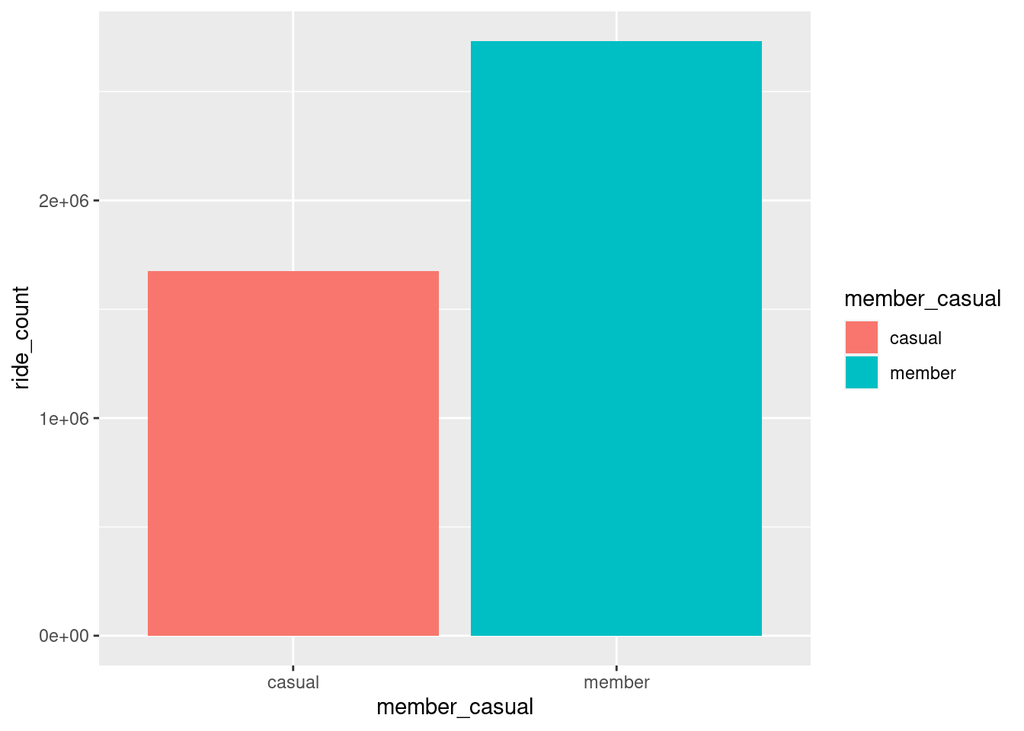

```r
processed_df %>%
  group_by(member_casual) %>%
  summarise(ride_count=n()) %>%
  ggplot(mapping=aes(x=member_casual, y = ride_count, fill=member_casual)) +
  geom_bar(stat='identity', position="dodge");
```

As expected, members use the bikes for more trips.

#### by month

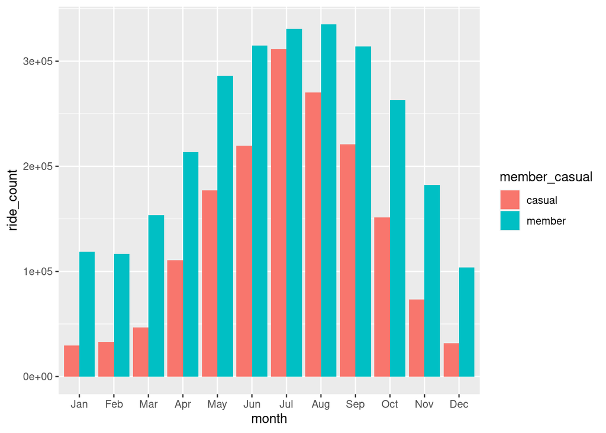

```r
processed_df %>%
  group_by(month, member_casual) %>%
  summarise(ride_count=n(), .groups="drop") %>%
  ggplot(mapping=aes(x=month, y = ride_count, fill=member_casual)) +
  geom_bar(stat='identity', position="dodge");
```

Both distributions are approximately normal. The members peak at August but the number of rides per month drops slowly around this peak. The casual riders peak at July. However, the values drop quickly around the peak. Both distributions could be attributed to the fact that more riders are expected around summer months (June - September).

#### by week day

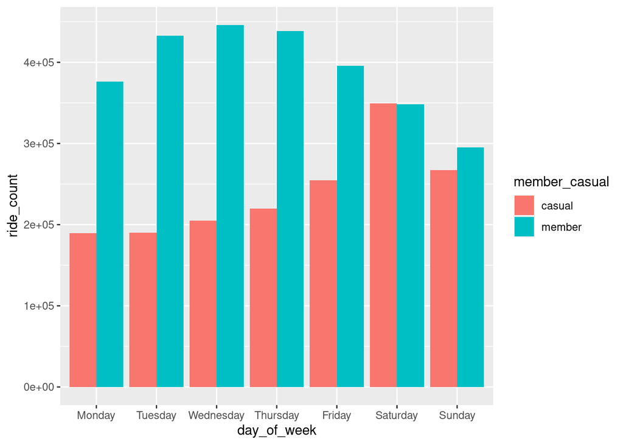

```r
processed_df$day_of_week <- ordered(processed_df$day_of_week,
                                         levels=c("Monday", "Tuesday", "Wednesday", "Thursday", "Friday", "Saturday", "Sunday"))

processed_df %>%
  group_by(day_of_week, member_casual) %>%
  summarise(ride_count=n(), .groups="drop") %>%
  ggplot(mapping=aes(x=day_of_week, y = ride_count, fill=member_casual)) +
  geom_bar(stat='identity', position="dodge");
```

Annual members use the bicycles more during the week. Casual riders prefer to use them during the weekend.

The explanation for this could be that members subscribe to access the bikes on daily basis like going to work. While casual riders rent them occasionally for entertainment on their free time in the weekend.

To test this theory more I am going to plot the distribution across each day of the week

#### by hour

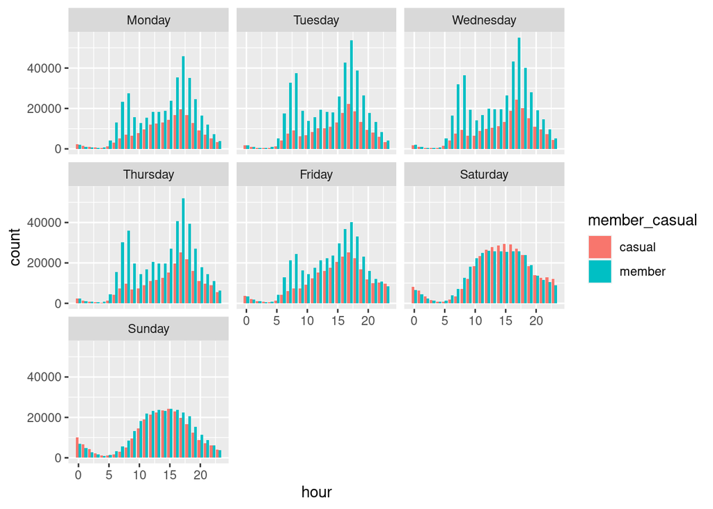

```r
processed_df %>%
  ggplot(aes(hour, fill=member_casual)) +
  geom_bar(position = "dodge") +
  facet_wrap(~day_of_week);
```

For weekdays, A lot of bikes are used from 5-10 am and 3-8 pm by members. these hours correspond to times where people are riding to or from work. Casual riders display a similar but diluted pattern. The distribution is almost identical for both categories in the weekend. This aids the conclusion that the bikes are used on the weekends for leisure purposes by members and casual riders

### 2 - rideable type

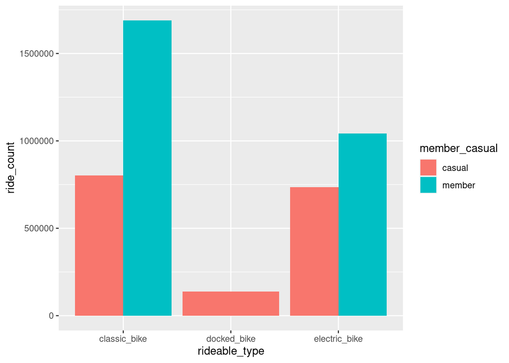

```r
processed_df %>%
  group_by(member_casual, rideable_type) %>%
  summarise(ride_count=n()) %>%
  ggplot(mapping=aes(x=rideable_type, y = ride_count, fill = member_casual)) +
  geom_bar(stat='identity', position='dodge');
```

### 3 - average distance of trips

#### Total

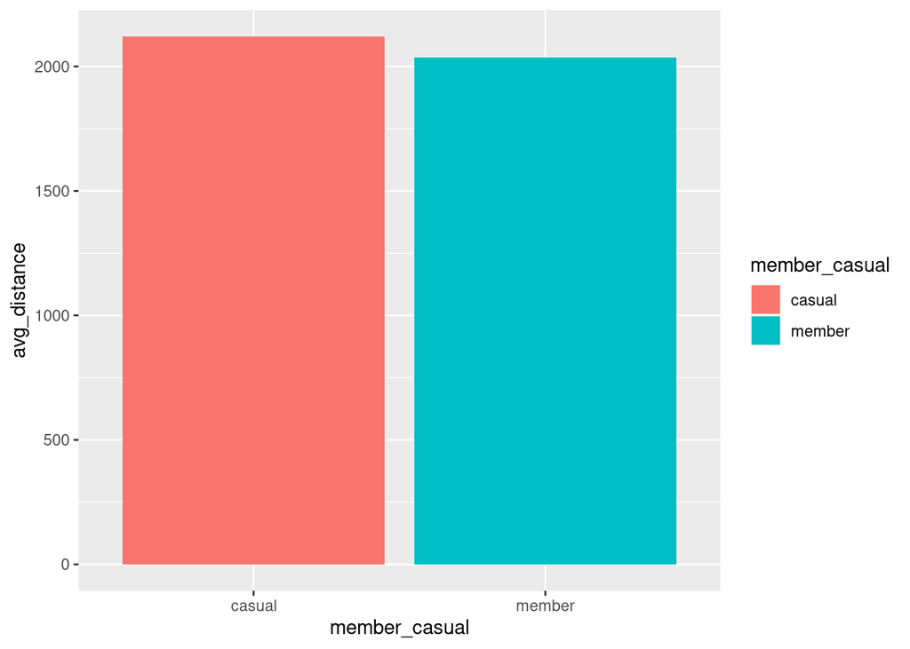

```r
processed_df %>%
  group_by(member_casual) %>%
  summarise(avg_distance=mean(distance)) %>%
  ggplot(mapping=aes(y = avg_distance, x=member_casual, fill = member_casual)) +
  geom_bar(stat='identity', position="dodge");
```

#### by month

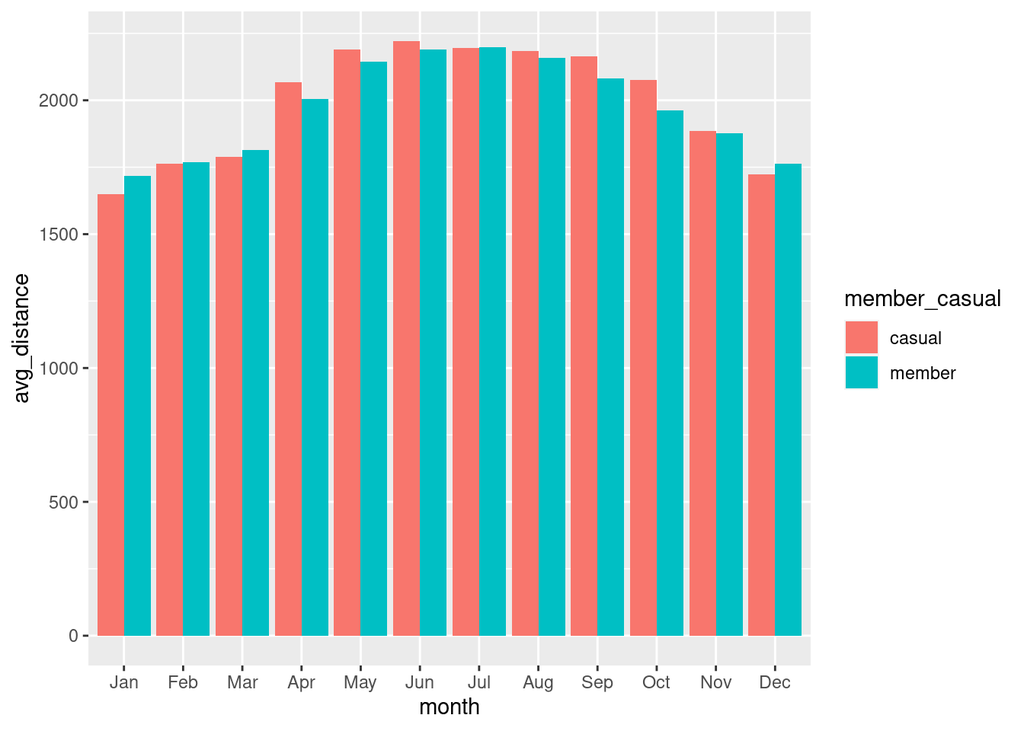

```r
processed_df %>%
  group_by(month, member_casual) %>%
  summarise(avg_distance = mean(distance), .groups="drop") %>%
  ggplot(mapping=aes(x=month, y = avg_distance, fill=member_casual)) +
  geom_bar(stat='identity', position="dodge");
```

#### by week day

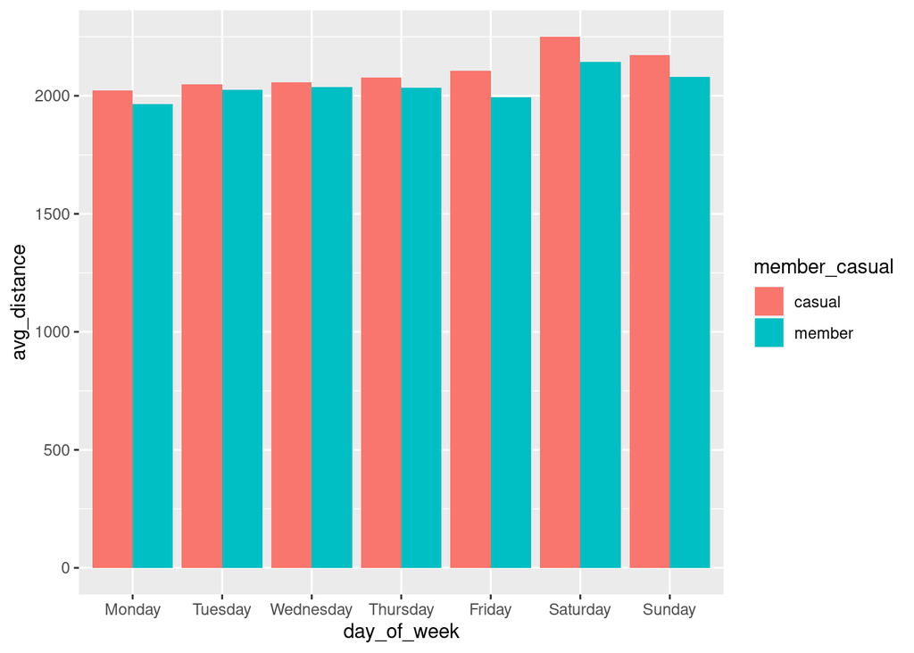

```r
processed_df$day_of_week <- ordered(processed_df$day_of_week,
                                         levels=c("Monday", "Tuesday", "Wednesday", "Thursday", "Friday", "Saturday", "Sunday"))

processed_df %>%
  group_by(day_of_week, member_casual) %>%
  summarise(avg_distance = mean(distance), .groups="drop") %>%
  ggplot(mapping=aes(x=day_of_week, y = avg_distance, fill=member_casual)) +
  geom_bar(stat='identity', position="dodge");
```

#### by hour

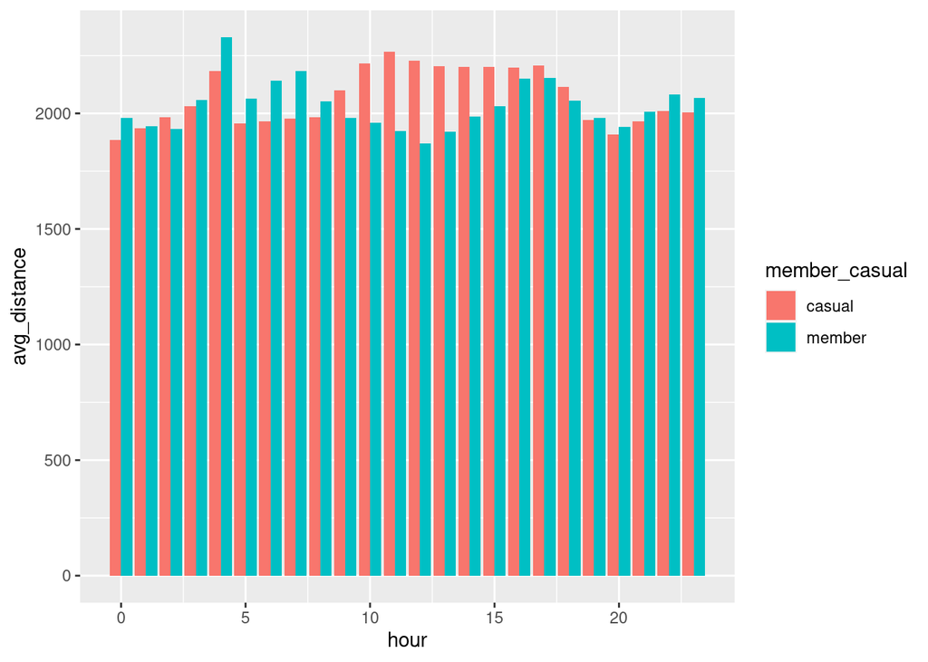

```r
processed_df %>%
  group_by(hour, member_casual) %>%
  summarise(avg_distance = mean(distance), .groups="drop") %>%
  ggplot(mapping=aes(x=hour, y = avg_distance, fill=member_casual)) +
  geom_bar(stat='identity', position="dodge");
```

The distance seems to be slightly more for casual riders. But the overall difference is very small. This makes sense because the data recorded tells the distance between the stations and not the actual distance covered.

### 4 - average duration of trips

#### Total

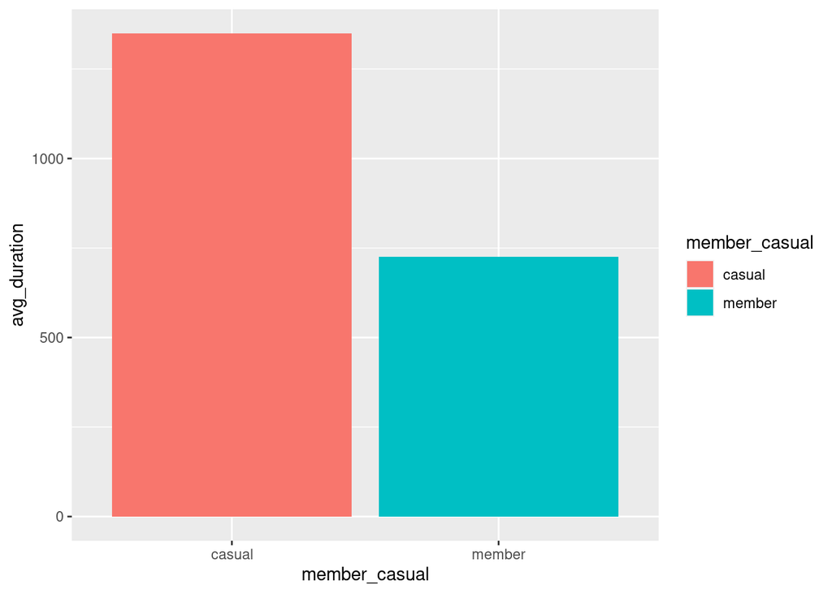

```r
processed_df %>%
  group_by(member_casual) %>%
  summarise(avg_duration=mean(duration), .groups = "drop") %>%
  ggplot(mapping=aes(y = avg_duration, x=member_casual, fill = member_casual)) +
  geom_bar(stat='identity', position="dodge");
```

The average casual rider takes double the trip duration.

#### by month

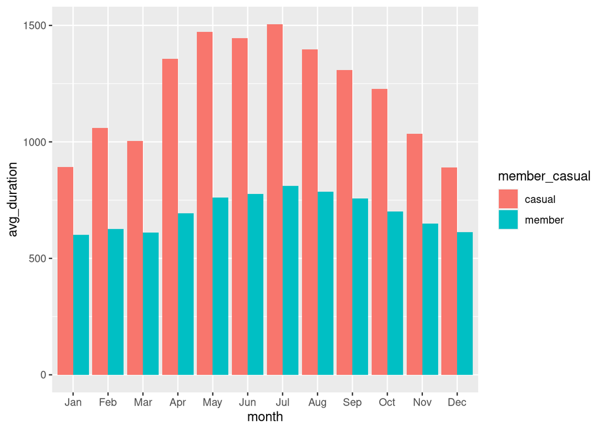

```r
processed_df %>%
  group_by(month, member_casual) %>%
  summarise(avg_duration = mean(duration), .groups="drop") %>%
  ggplot(mapping=aes(x=month, y = avg_duration, fill=member_casual)) +
  geom_bar(stat='identity', position="dodge");
```

This phenomen holds for every month of the year

#### by week day

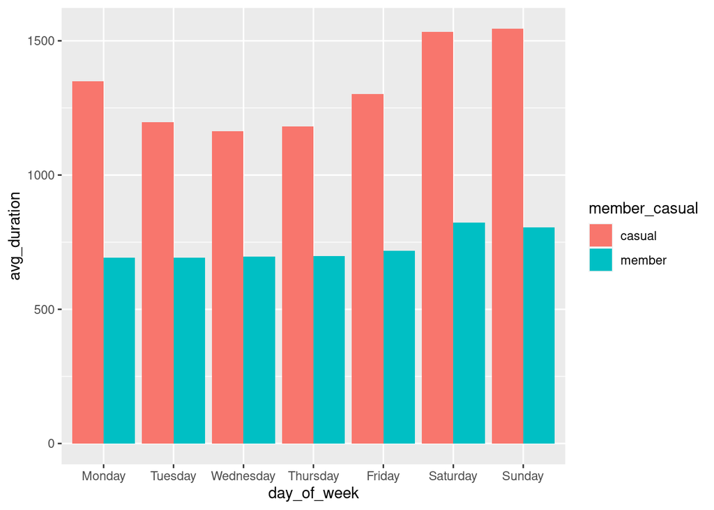

```r
processed_df$day_of_week <- ordered(processed_df$day_of_week,
                                         levels=c("Monday", "Tuesday", "Wednesday", "Thursday", "Friday", "Saturday", "Sunday"))

processed_df %>%
  group_by(day_of_week, member_casual) %>%
  summarise(avg_duration = mean(duration), .groups="drop") %>%
  ggplot(mapping=aes(x=day_of_week, y = avg_duration, fill=member_casual)) +
  geom_bar(stat='identity', position="dodge");
```

#### by hour

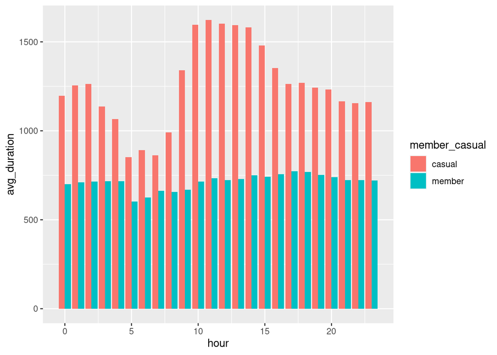

```r
processed_df %>%
  group_by(hour, member_casual) %>%
  summarise(avg_duration = mean(duration), .groups="drop") %>%
  ggplot(mapping=aes(x=hour, y = avg_duration, fill=member_casual)) +
  geom_bar(stat='identity', position="dodge");
```

Conclusion: The casual riders take the bikes for longer trips

## V: Share and Act

### Findings:

- The company’s services are mostly used during the Summer
- annual members use Cyclistic’s services significantly more at work hours. Other than that the usage is similar between the two categories
- casual riders ride more on the weekends
- docked bikes are used by casual riders only
- the distance between the start and end points is independent of the category
- casual riders prefer to take longer duration trips

### Suggestions

- Offer weekend specific memberships to attract more casual riders
- Offer discounts for longer trips

### Further analysis

- survey customers on their purpose for using Cyclistic’s services
- record customer id to calculate frequency of usage by each category